# echolocatoR: full pipeline vignette

Brian M. Schilder

Most recent update: 2020-06-18

```r
library(echolocatoR)
```

# Full pipeline

All examples below use data from the Parkinson’s disease GWAS by Nalls et al. (2019).

## Prepare `top_SNPs` data.frame

- To enable rapid fine-mapping of many loci, you can create a `top_SNPs` data.frame  
  which contains the position of the lead/index SNP within each locus.
- `finemap_loci()` (see next step) will then use this info to extract subsets of the  
  full GWAS/QTL summary statistics using windows centered on each lead/index SNP.
- The `topSS` argument can either be a data.frame, or a path to a topSS file saved somehwere. Most common tabular data formats (e.g. .tsv, .csv, .xlsx) are accepted.

```r
data("Nalls_top_SNPs");
top_SNPs <- import_topSNPs(
  # topSS = "~/Desktop/Fine_Mapping/Data/GWAS/Nalls23andMe_2019/Nalls2019_TableS2.xlsx",
  topSS = Nalls_top_SNPs,
  chrom_col = "CHR", position_col = "BP", snp_col="SNP",
  pval_col="P, all studies", effect_col="Beta, all studies", gene_col="Nearest Gene",
  group_by_locus = T,
  locus_col = "Nearest Gene",
  remove_variants = "rs34637584")
```

## Find path to full summary stats file

- Since a full GWAS summary stats file would be too large to include within *echolocatoR*,  
  we instead provide a example subset of the full summary stats.
- To simulate how you’d actually use your own full summary stats file, we will save our example dataset to your computer (you can change the path to wherever you like).

```r
fullSS_path <- example_fullSS(fullSS_path="~/Desktop/Nalls23andMe_2019.fullSS_subset.tsv")
```

## Run fine-mapping pipeline

For a full description of all arguments, see `?finemap_loci`.

Here are some key arguments:

- *results_dir*: Where you want to store all of your results.
- *finemap_methods*: Which fine-mapping methods you want to run (currently includes ABF, FINEMAP, SUSIE, POLYFUN_SUSIE, and COJO).
- *bp_distance*: Controls window size. Specifically, `bp_distance` is the number of basepairs upstream/downstream you want to extract for each locus. For example, if you want a 2Mb window (+/- 1Mb from the lead/index SNP in `top_SNPs`), set `bp_distance=1e+06`.
- *plot.window*: Zoom in/out from the center of each locus when producing the multiview plot.  
  You can adjust this separately from `bp_distance` so that you don’t have rerun the whole pipeline each time (locus subsets, LD matrices, and fine-mapping results are all automatically saved in locus-specific folders).

```
#> 🦇 🦇 🦇 BST1 🦇 🦇 🦇
#> ------------------ Step 1: Query ---------------
#> [1] "+ Extracting relevant variants from fullSS..."
#> [1] "++ Query Method: 'tabix"
#> [1] "---Min snp position: 14737348 ---"
#> [1] "---Max snp position: 16737348 ---"
#> [1] "TABIX:: Existing indexed tabix file detected"
#> [1] "TABIX:: Extracting subset of sum stats"
#> [1] "++ Returning 6282 x 11 data.table"
#> [1] "++ Saving query ==> ~/Desktop/results/GWAS/Nalls23andMe_2019/BST1/BST1_Nalls23andMe_2019_subset.tsv.gz"
#> [1] ""
#> ---------------- Step 1.5: Standardize ----------
#> [1] "+Inferring MAF from frequency column..."
#> [1] "+ Standardize:: Calculating proportion of cases."
#> [1] "+ Calculating t-statistic from Effect and StdErr..."
```

[output cut: 54 more lines]

```
#> Fine-mappping complete:BST1
#> Time difference of 1.1 mins
#> 🦇 🦇 🦇 MEX3C 🦇 🦇 🦇
#> ------------------ Step 1: Query ---------------
#> [1] "+ Extracting relevant variants from fullSS..."
#> [1] "++ Query Method: 'tabix"
#> [1] "---Min snp position: 47683589 ---"
#> [1] "---Max snp position: 49683589 ---"
#> [1] "TABIX:: Existing indexed tabix file detected"
#> [1] "TABIX:: Extracting subset of sum stats"
#> [1] "++ Returning 5405 x 11 data.table"
#> [1] "++ Saving query ==> ~/Desktop/results/GWAS/Nalls23andMe_2019/MEX3C/MEX3C_Nalls23andMe_2019_subset.tsv.gz"
#> [1] ""
#> ---------------- Step 1.5: Standardize ----------
#> [1] "+Inferring MAF from frequency column..."
#> [1] "+ Standardize:: Calculating proportion of cases."
#> [1] "+ Calculating t-statistic from Effect and StdErr..."
#> [1] "+ Extraction completed in 1.01 seconds"
#> [1] "+ 5399 SNPs x  15 columns"
#> [1] "+ Removing subset tmp..."
#> --- Step 2: Calculate Linkage Disequilibrium ---
#> [1] "LD:: Using UK Biobank LD reference panel..."
#> [1] "+ UKB LD file name: chr18_47000001_50000001"
#> [1] "+ LD:: Pre-existing UKB_LD.RDS file detected. Importing..."
#> -------------- Step 3: Filter SNPs -------------
#> [1] "++ Post-filtered data: 5399 x 15"
#> -------- Step 4: Statistically Fine-map --------
#> [1] "++ Previously multi-fine-mapped results identified. Importing..."
#> [1] "++ Fine-mapping with ' ABF, SUSIE, FINEMAP ' completed in  0.07"
#> [1] "+ Identifying Consensus SNPs..."
#> [1] "++ support_thresh = 2"
#> [1] "+ Calculating mean Posterior Probability (mean.PP)..."
#> [1] "++ 3 fine-mapping methods used."
#> [1] "++ 1 Credible Set SNPs identified."
#> [1] "++ 0 Consensus SNPs identified."
#> --------------- Step 7: Visualize --------------
#> [1] "+ Identifying Consensus SNPs..."
#> [1] "++ support_thresh = 2"
#> [1] "+ Calculating mean Posterior Probability (mean.PP)..."
#> [1] "++ 3 fine-mapping methods used."
```

[output cut: 24 more lines]

[output not shown]

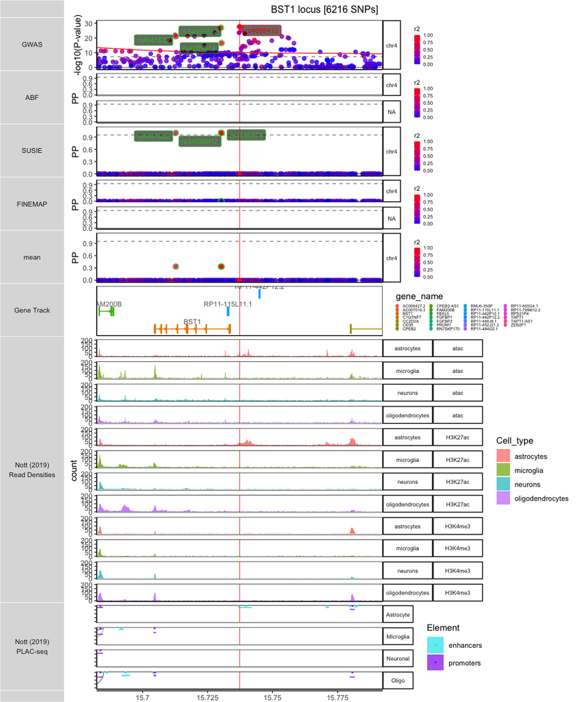

```
#> Fine-mappping complete:MEX3C
```

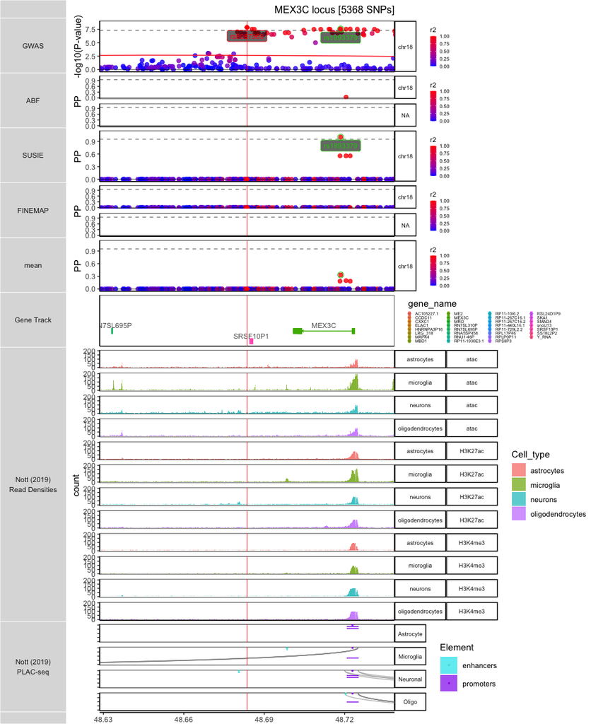

[output not shown]

```r
Nalls23andMe_2019.results <- finemap_loci(# GENERAL ARGUMENTS
                                          top_SNPs = top_SNPs,
                                          results_dir = "~/Desktop/results",
                                          loci = c("BST1","MEX3C"),#top_SNPs$Gene,
                                          dataset_name = "Nalls23andMe_2019",
                                          dataset_type = "GWAS",
                                          force_new_subset = T,
                                          force_new_LD = F,
                                          force_new_finemap = F,
                                          remove_tmps = T,

                 # SUMMARY STATS ARGUMENTS
                 fullSS_path = fullSS_path,
                 query_by ="tabix",
                 chrom_col = "CHR", position_col = "POS", snp_col = "RSID",
                 pval_col = "p", effect_col = "beta", stderr_col = "se",
                 freq_col = "freq", MAF_col = "calculate",
                 A1_col = "A1",
                 A2_col = "A2",

                 # FILTERING ARGUMENTS
                 bp_distance = 500000*2,
                 min_MAF = 0.001,
                 trim_gene_limits = F,

                 # FINE-MAPPING ARGUMENTS
                 finemap_methods = c("ABF","SUSIE","FINEMAP"),
                 n_causal = 5,
                 PP_threshold = .95,

                 # LD ARGUMENTS
                 LD_reference = "UKB",#"1KG_Phase1",
                 superpopulation = "EUR",
                 LD_download_method = "axel",

                 # PLOT ARGUMENTS
                 ## general
                 plot.types=c("fancy"),
                 plot.window = 100000,
                 ## XGR
                 # plot.XGR_libnames=c("ENCODE_TFBS_ClusteredV3_CellTypes"),
                 ## Roadmap
                 plot.Roadmap = F,
                 plot.Roadmap_query = NULL,
                 # Nott et al. (2019)
                 plot.Nott_epigenome = T,
                 plot.Nott_binwidth = 100
                 )
```